# Web Exercises

**What is a confounder?**

**What is a mediator?**

A variable that changes the strength or direction of the relationship between the predictor and the outcome A variable that is influenced by the predictor and in turn influences the outcome A variable that is associated with the outcome but not the predictor A variable that the predictor but not the outcome

**What is a collider?**

A variable that is influenced by the predictor and in turn influences the outcome A variable that is associated with both the predictor and the outcome A variable that is caused by both the predictor and the outcome A variable that changes the strength or direction of the relationship between the predictor and the outcome

**What are bad controls?** You can select multiple answers for this question

Both mediators and colliders are cases of bad controls Variables that look like sensible adjustments but actively distort the estimate of the intervention effect. Variables that if adjusted for, will reduce bias in the estimate of the intervention effect A confounder is a case of a bad control

**Based on the DAG below, select the correct answer(s).**

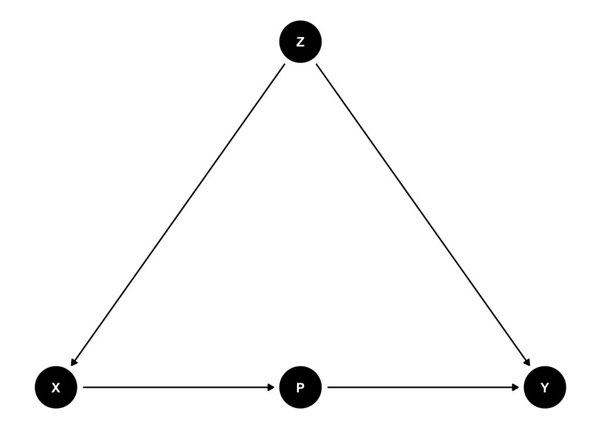

P and Z should be adjusted for P is a mediator so it should be adjusted for Z is a confounder so it should be adjusted for Z is a collider so it should be adjusted for

**What is the correct statistical model to estimate the effect of X on Y?**

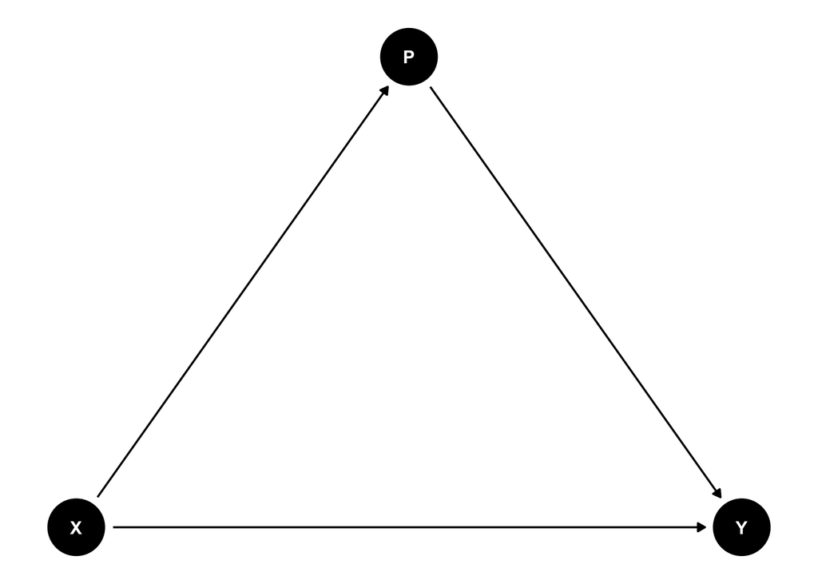

Y ~ X + P Y ~ X + I(P) Y ~ X Y ~ X + P + X:P

**Suppose that the causal effect of intervention X on Y is 2. You have a confounder C that is correlated with both X and Y. You run two linear models `m1 = lm(Y ~ X)` and `m2 = lm(Y ~ X + C)`. What is the consequence of including C in the model?**

| Model | Intercept | Estimate | SE |
| --- | --- | --- | --- |
| m1 | 1.49 | 2.51 | 0.0087 |
| m2 | 0.97 | 2.00 | 0.0100 |

It does not matter because both models return very small standard errors (SE) A more accurate estimate of the effect X on Y, closer to the true causal effect of 2 A smaller intercept, which is good because the smaller the less biased Still a biased estmate of the effect of X on Y because it is smaller than 2

**The first model estimates the relationship between X and Y without adjusting for the mediator M, whereas the second model additionally adjusts for M. Based on the two models, which statement best describes the effect of X on Y?**

| Model | Estimate | SE |
| --- | --- | --- |
| m1 | 1.03 | 0.0142 |
| m2 | 0.02 | 0.0142 |

The first model estimates the total effect of X on Y, while the second estimates the direct effect of X on Y The second model provides a more accurate estimate of the total effect because it accounts for the pathway through M Both models estimate the total effect of X on Y because adjusting for M does not affect the interpretation of the coefficient for X The first model estimates the direct effect of X on Y, while the second estimates the total effect

**Based on the two models above, what is the causal effect of X on Y?**

**Can you make causal claims based on observational data?**

No, because the data is observational and not a randomized controlled trial Yes, but researchers need to think carefully about good controls that might bias the estimate of the causal effect No, because observational data suffers from confounding and cannot be used to make causal claims Yes, but researchers need to think carefully about bad controls that might bias the estimate of the causal effect B and D

**What is the effect of adjusting for Z in the statistical model?**

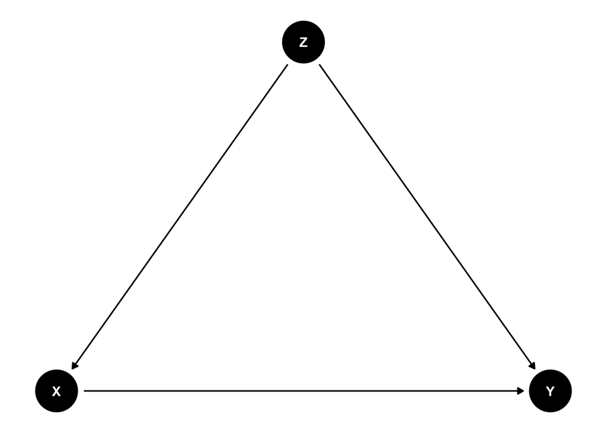

Adjusting will reduce bias in the estimate of the effect of X on Y It depends on the research question and the context of the study It can induce a non-causal association between X and Y leading to a biased estimate of the effect of X on Y Adjusting will have no effect on the estimate of the effect of X on Y and it will also reduce the SE of the estimate thus increasing the precision of the estimate